# Project: Movie Data Analysis

- Introduction
- Data Wrangling
- Exploratory Data Analysis
- Conclusions

## Introduction

In this project, we will analyse the [TMBD](https://www.themoviedb.org/) movie dataset, provided within the course and cleaned from original data on [Kaggle](https://www.kaggle.com/tmdb/tmdb-movie-metadata). The original dataset was created on 30 August 2016, and lastly updated on 28 September 2017.

Here is a short overview of the features:

- **id** - the movie [TMBD](https://www.themoviedb.org/) id
- **imdb_id** - the movie [IMDb](https://www.imdb.com/?ref_=nv_home) id
- **popularity** - metric built on characteristics such as number of votes and views for the day, number of users who marked the movie as a "favourite" or who added the movie to their "watchlist" for the day etc. (more details can be found in [Popularity](https://developers.themoviedb.org/3/getting-started/popularity))
- **budget** - the budget in US dollars
- **revenue** - the revenue in US dollars
- **original_title** - the movie title
- **cast** - the list of the main performers
- **homepage** - the movie web page
- **director** - the movie director
- **tagline** - a short text which serves to clarify a thought for, or is designed with a form of, dramatic effect ([Wiki](https://en.wikipedia.org/wiki/Tagline))
- **keywords** - keywords associated with the movie
- **overview** - a short description of the movie
- **runtime** - the movie length in minutes
- **genres** - the list of genres the movie belongs to
- **production_companies** - the list of production companies
- **release_date** - the movie release date
- **vote_count** - the number of users that rated the movie
- **vote_average** - the average rating of the movie
- **release_year** - the movie release year
- **budget_adj** - the budget in terms of 2010 dollars, accounting for inflation over time
- **revenue_adj** - the revenue in terms of 2010 dollars, accounting for inflation over time

We will analyse the dataset to shed light on following questions:

1. Is there correlation between budget and revenue?
2. Which genres are associated with high revenues?
3. What is the optimal movie runtime with respect to revenue?
4. Are movies with high revenues rated highly by users?

Following features will be used to answer the questions:

- **budget_adj** and **revenue_adj** - we will use adjusted values to compare movies released in different decades consistently
- **genres**
- **vote_average** - we will use this as a measure of movie popularity, it's basically user rating ranging from 0 to 10
- **runtime**

We will keep **id**, **original_title** and **release_year** in order to identify the movies.

We will use descriptive statistics; inferential statistics or machine learning are not used to complete the project, and from this point of view, the findings are tentative and open to further exploration.

```python
# Import packages
import numpy as np
import pandas as pd
import matplotlib.pyplot as plt
import seaborn as sns

# Import scipy to perform linear regression
from scipy import stats

# Set matplotlib backend
%matplotlib inline

# Set seaborn-like style
sns.set_style('white')
```

## Data Wrangling

Let's examine the dataset and perform necessary cleaning steps.

### General Properties

First, the dataset is loaded into a pandas dataframe in order to explore general properties of the data and decide, which cleaning steps will be applied. We will focus on features that will be used in exploratory data analysis.

```python
# Load the movie dataset (the csv file is stored in the local folder 'data')
file = 'data/tmdb-movies.csv'
df = pd.read_csv(file)
```

```python
# View the first few lines of the dataset
df.head()
```

|  | id | imdb_id | popularity | budget | revenue | original_title | cast | homepage | director | tagline | ... | overview | runtime | genres | production_companies | release_date | vote_count | vote_average | release_year | budget_adj | revenue_adj |
| --- | --- | --- | --- | --- | --- | --- | --- | --- | --- | --- | --- | --- | --- | --- | --- | --- | --- | --- | --- | --- | --- |
| 0 | 135397 | tt0369610 | 32.985763 | 150000000 | 1513528810 | Jurassic World | Chris Pratt\|Bryce Dallas Howard\|Irrfan Khan\|Vi... | http://www.jurassicworld.com/ | Colin Trevorrow | The park is open. | ... | Twenty-two years after the events of Jurassic ... | 124 | Action\|Adventure\|Science Fiction\|Thriller | Universal Studios\|Amblin Entertainment\|Legenda... | 6/9/15 | 5562 | 6.5 | 2015 | 1.379999e+08 | 1.392446e+09 |
| 1 | 76341 | tt1392190 | 28.419936 | 150000000 | 378436354 | Mad Max: Fury Road | Tom Hardy\|Charlize Theron\|Hugh Keays-Byrne\|Nic... | http://www.madmaxmovie.com/ | George Miller | What a Lovely Day. | ... | An apocalyptic story set in the furthest reach... | 120 | Action\|Adventure\|Science Fiction\|Thriller | Village Roadshow Pictures\|Kennedy Miller Produ... | 5/13/15 | 6185 | 7.1 | 2015 | 1.379999e+08 | 3.481613e+08 |
| 2 | 262500 | tt2908446 | 13.112507 | 110000000 | 295238201 | Insurgent | Shailene Woodley\|Theo James\|Kate Winslet\|Ansel... | http://www.thedivergentseries.movie/#insurgent | Robert Schwentke | One Choice Can Destroy You | ... | Beatrice Prior must confront her inner demons ... | 119 | Adventure\|Science Fiction\|Thriller | Summit Entertainment\|Mandeville Films\|Red Wago... | 3/18/15 | 2480 | 6.3 | 2015 | 1.012000e+08 | 2.716190e+08 |
| 3 | 140607 | tt2488496 | 11.173104 | 200000000 | 2068178225 | Star Wars: The Force Awakens | Harrison Ford\|Mark Hamill\|Carrie Fisher\|Adam D... | http://www.starwars.com/films/star-wars-episod... | J.J. Abrams | Every generation has a story. | ... | Thirty years after defeating the Galactic Empi... | 136 | Action\|Adventure\|Science Fiction\|Fantasy | Lucasfilm\|Truenorth Productions\|Bad Robot | 12/15/15 | 5292 | 7.5 | 2015 | 1.839999e+08 | 1.902723e+09 |
| 4 | 168259 | tt2820852 | 9.335014 | 190000000 | 1506249360 | Furious 7 | Vin Diesel\|Paul Walker\|Jason Statham\|Michelle ... | http://www.furious7.com/ | James Wan | Vengeance Hits Home | ... | Deckard Shaw seeks revenge against Dominic Tor... | 137 | Action\|Crime\|Thriller | Universal Pictures\|Original Film\|Media Rights ... | 4/1/15 | 2947 | 7.3 | 2015 | 1.747999e+08 | 1.385749e+09 |

5 rows × 21 columns

```python
# View the full record of the first movie
df.iloc[0]
```

```
id                                                                 135397
imdb_id                                                         tt0369610
popularity                                                        32.9858
budget                                                          150000000
revenue                                                        1513528810
original_title                                             Jurassic World
cast                    Chris Pratt|Bryce Dallas Howard|Irrfan Khan|Vi...
homepage                                    http://www.jurassicworld.com/
director                                                  Colin Trevorrow
tagline                                                 The park is open.
keywords                monster|dna|tyrannosaurus rex|velociraptor|island
overview                Twenty-two years after the events of Jurassic ...
runtime                                                               124
genres                          Action|Adventure|Science Fiction|Thriller
production_companies    Universal Studios|Amblin Entertainment|Legenda...
release_date                                                       6/9/15
vote_count                                                           5562
vote_average                                                          6.5
release_year                                                         2015
budget_adj                                                       1.38e+08
revenue_adj                                                   1.39245e+09
Name: 0, dtype: object
```

The column names are already in good shape - they are clear, short and self-explanatory, and are in lowercase with underscores separating names consisting of more than one word. Some of the columns contain values separated by '|'.

How big is the dataset?

```python
# The size of the dataset
df.shape
```

```
(10866, 21)
```

The movie dataset contains 10866 rows (records) and 21 columns (features), which would be data for 10866 movies provided that there are no duplicates. We'll check for duplicates later.

Let's explore the dataset further:

```python
# Print general information about the dataset
df.info()
```

```
<class 'pandas.core.frame.DataFrame'>
RangeIndex: 10866 entries, 0 to 10865
Data columns (total 21 columns):
id                      10866 non-null int64
imdb_id                 10856 non-null object
popularity              10866 non-null float64
budget                  10866 non-null int64
revenue                 10866 non-null int64
original_title          10866 non-null object
cast                    10790 non-null object
homepage                2936 non-null object
director                10822 non-null object
tagline                 8042 non-null object
keywords                9373 non-null object
overview                10862 non-null object
runtime                 10866 non-null int64
genres                  10843 non-null object
production_companies    9836 non-null object
release_date            10866 non-null object
vote_count              10866 non-null int64
vote_average            10866 non-null float64
release_year            10866 non-null int64
budget_adj              10866 non-null float64
revenue_adj             10866 non-null float64
dtypes: float64(4), int64(6), object(11)
memory usage: 1.3+ MB
```

Column containing movie genres has some missing values; all other features we plan to use don't have any missing values.

```python
# Check minimum, maximum, average, and other properties for numeric features
df.describe()
```

|  | id | popularity | budget | revenue | runtime | vote_count | vote_average | release_year | budget_adj | revenue_adj |
| --- | --- | --- | --- | --- | --- | --- | --- | --- | --- | --- |
| count | 10866.000000 | 10866.000000 | 1.086600e+04 | 1.086600e+04 | 10866.000000 | 10866.000000 | 10866.000000 | 10866.000000 | 1.086600e+04 | 1.086600e+04 |
| mean | 66064.177434 | 0.646441 | 1.462570e+07 | 3.982332e+07 | 102.070863 | 217.389748 | 5.974922 | 2001.322658 | 1.755104e+07 | 5.136436e+07 |
| std | 92130.136561 | 1.000185 | 3.091321e+07 | 1.170035e+08 | 31.381405 | 575.619058 | 0.935142 | 12.812941 | 3.430616e+07 | 1.446325e+08 |
| min | 5.000000 | 0.000065 | 0.000000e+00 | 0.000000e+00 | 0.000000 | 10.000000 | 1.500000 | 1960.000000 | 0.000000e+00 | 0.000000e+00 |
| 25% | 10596.250000 | 0.207583 | 0.000000e+00 | 0.000000e+00 | 90.000000 | 17.000000 | 5.400000 | 1995.000000 | 0.000000e+00 | 0.000000e+00 |
| 50% | 20669.000000 | 0.383856 | 0.000000e+00 | 0.000000e+00 | 99.000000 | 38.000000 | 6.000000 | 2006.000000 | 0.000000e+00 | 0.000000e+00 |
| 75% | 75610.000000 | 0.713817 | 1.500000e+07 | 2.400000e+07 | 111.000000 | 145.750000 | 6.600000 | 2011.000000 | 2.085325e+07 | 3.369710e+07 |
| max | 417859.000000 | 32.985763 | 4.250000e+08 | 2.781506e+09 | 900.000000 | 9767.000000 | 9.200000 | 2015.000000 | 4.250000e+08 | 2.827124e+09 |

Columns vote_average and release_year have expected, reasonable values for minimum, maximum and other properties. On the other hand, budget_adj, revenue_adj and runtime have minimum equal to 0, which is not quite expected. Furthermore, median values for both budget_adj and revenue_adj are also 0. It seems that '0' represent missing values for these features and we will treat them later in the cleaning phase.

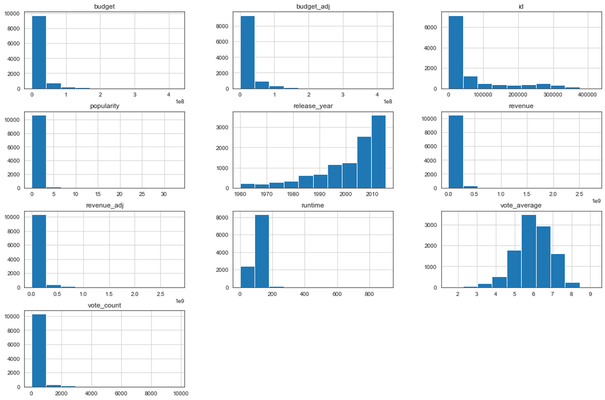

```python
# Visualize the distributions of the numeric features to get a better picture
df.hist(figsize=(18,12));
```

Histograms support the observations above:

- The number of movies released every year increases over time, which is expected. There are no obvious odd values.
- The movie rating represented by feature vote_average follows a normal distribution - there are many average movies, some very bad movies with low rating below 3 and some very good movies with high rating above 8.
- Most of the movies have popularity below 1. Since it is a little bit difficult to relate to this measure, i.e. it is not clear, what the normal values should be, we will not use this measure in the subsequent analysis.
- The median runtime is 99 minutes - approximately one hour and forty minutes. However, there are also some extremely long movies.
- Budget and revenue histograms are skewed to the right, which could be because many movies have zero, probably missing, budget and revenue. However, there might be movies with extremely low budget anyway.

(Note: We printed out information about all numeric features to get a better overview of the data, although we will not use all data further.)

```python
# Let's check non-numeric features of our interest
df[['original_title', 'genres']].describe()
```

|  | original_title | genres |
| --- | --- | --- |
| count | 10866 | 10843 |
| unique | 10571 | 2039 |
| top | Hamlet | Comedy |
| freq | 4 | 712 |

The most frequent movie title is 'Hamlet' and the most frequent genre is 'Comedy'. There are 2039 unique values for genres. While the title is, similarly to id, just an identifier, we will further concentrate only on genres when it comes to non-numeric features. Feature genres is basically a combination of basic types such as drama, comedy, fantasy, horror, thriller, etc. We will use it as is, because e.g. genre described as action/fantasy is qualitatively different than action or fantasy, from our point of view.

#### Datatypes

Let's check whether the datatypes are correct and focus on features that will be used in the analysis.

```python
# Overview of the features and their datatypes
df.info()
```

```
<class 'pandas.core.frame.DataFrame'>
RangeIndex: 10866 entries, 0 to 10865
Data columns (total 21 columns):
id                      10866 non-null int64
imdb_id                 10856 non-null object
popularity              10866 non-null float64
budget                  10866 non-null int64
revenue                 10866 non-null int64
original_title          10866 non-null object
cast                    10790 non-null object
homepage                2936 non-null object
director                10822 non-null object
tagline                 8042 non-null object
keywords                9373 non-null object
overview                10862 non-null object
runtime                 10866 non-null int64
genres                  10843 non-null object
production_companies    9836 non-null object
release_date            10866 non-null object
vote_count              10866 non-null int64
vote_average            10866 non-null float64
release_year            10866 non-null int64
budget_adj              10866 non-null float64
revenue_adj             10866 non-null float64
dtypes: float64(4), int64(6), object(11)
memory usage: 1.3+ MB
```

```python
# Check datatype of genres
type(df['genres'][0])
```

```
str
```

```python
# Check datatype of id and title
type(df['id'][0]), type(df['original_title'][0])
```

```
(numpy.int64, str)
```

Budget, revenue and vote average are floats, runtime is integer, and genres is of type string. For the completeness, the datatype of original title is string, the movie id and release year are integers. The datatypes are fine and we will not convert any of them.

#### Duplicates

Are there any movies that are duplicates? If yes, is it a full duplicate (all column values are exactly the same) or a partial duplicate (some of the values are the same)? In the latter case, it might not be a duplicate at all, but just a different movie.

Next, we will check if there are any full duplicates and if there are any partial duplicates, i.e. any movies with the same title and release year. We could select another features, but the title and release year are available for all of the movies, and they could be considered as a unique identifier for each movie. However, we will check also duplicates in terms of the movie id, which is a unique identifier for each movie.

**Full duplicates:**

```python
# Full duplicates
df.duplicated().sum()
```

```
1
```

It appears that there is precisely one movie that occurs in the dataset twice. Let's have a look at it:

```python
# View the duplicate
df[df.duplicated(keep=False)]
```

|  | id | imdb_id | popularity | budget | revenue | original_title | cast | homepage | director | tagline | ... | overview | runtime | genres | production_companies | release_date | vote_count | vote_average | release_year | budget_adj | revenue_adj |
| --- | --- | --- | --- | --- | --- | --- | --- | --- | --- | --- | --- | --- | --- | --- | --- | --- | --- | --- | --- | --- | --- |
| 2089 | 42194 | tt0411951 | 0.59643 | 30000000 | 967000 | TEKKEN | Jon Foo\|Kelly Overton\|Cary-Hiroyuki Tagawa\|Ian... | NaN | Dwight H. Little | Survival is no game | ... | In the year of 2039, after World Wars destroy ... | 92 | Crime\|Drama\|Action\|Thriller\|Science Fiction | Namco\|Light Song Films | 3/20/10 | 110 | 5.0 | 2010 | 30000000.0 | 967000.0 |
| 2090 | 42194 | tt0411951 | 0.59643 | 30000000 | 967000 | TEKKEN | Jon Foo\|Kelly Overton\|Cary-Hiroyuki Tagawa\|Ian... | NaN | Dwight H. Little | Survival is no game | ... | In the year of 2039, after World Wars destroy ... | 92 | Crime\|Drama\|Action\|Thriller\|Science Fiction | Namco\|Light Song Films | 3/20/10 | 110 | 5.0 | 2010 | 30000000.0 | 967000.0 |

2 rows × 21 columns

Verify whether there are any movies with the same id:

```python
# Duplicates with the same id
df.duplicated(subset=['id'], keep=False).sum()
```

```
2
```

There are two movies, or better said, rows that have the same movie id - again, it would be the movie called 'TEKKEN'. We will drop the duplicate later on.

**Partial duplicates:**  
Let's find out whether there are other duplicates - consider the title and release year (both have zero null values, on the contrary to columns such as director):

```python
# Duplicates with the same title and release year
df.duplicated(subset=['original_title', 'release_year']).sum()
```

```
4
```

There are 4 movies with the same title and release year. Let's check them:

```python
# Let's view those movies with the same title and release year (filter out the full duplicate)
df[df.duplicated(subset=['original_title', 'release_year'], keep=False)]
```

|  | id | imdb_id | popularity | budget | revenue | original_title | cast | homepage | director | tagline | ... | overview | runtime | genres | production_companies | release_date | vote_count | vote_average | release_year | budget_adj | revenue_adj |
| --- | --- | --- | --- | --- | --- | --- | --- | --- | --- | --- | --- | --- | --- | --- | --- | --- | --- | --- | --- | --- | --- |
| 2089 | 42194 | tt0411951 | 0.596430 | 30000000 | 967000 | TEKKEN | Jon Foo\|Kelly Overton\|Cary-Hiroyuki Tagawa\|Ian... | NaN | Dwight H. Little | Survival is no game | ... | In the year of 2039, after World Wars destroy ... | 92 | Crime\|Drama\|Action\|Thriller\|Science Fiction | Namco\|Light Song Films | 3/20/10 | 110 | 5.0 | 2010 | 3.000000e+07 | 9.670000e+05 |
| 2090 | 42194 | tt0411951 | 0.596430 | 30000000 | 967000 | TEKKEN | Jon Foo\|Kelly Overton\|Cary-Hiroyuki Tagawa\|Ian... | NaN | Dwight H. Little | Survival is no game | ... | In the year of 2039, after World Wars destroy ... | 92 | Crime\|Drama\|Action\|Thriller\|Science Fiction | Namco\|Light Song Films | 3/20/10 | 110 | 5.0 | 2010 | 3.000000e+07 | 9.670000e+05 |
| 2508 | 11944 | tt0178145 | 0.406308 | 20000000 | 0 | Joan of Arc | Leelee Sobieski\|Powers Boothe\|Neil Patrick Har... | NaN | Christian Duguay | She died at 19. 500 years later her legend liv... | ... | Ten years before her death, Joan hears voices.... | 140 | Drama\|History | NaN | 5/16/99 | 13 | 5.8 | 1999 | 2.618106e+07 | 0.000000e+00 |
| 2571 | 10047 | tt0151137 | 0.235223 | 60000000 | 66976317 | Joan of Arc | Milla Jovovich\|Dustin Hoffman\|Faye Dunaway\|Joh... | NaN | Luc Besson | NaN | ... | In 1429 a teenage girl from a remote French vi... | 148 | Adventure\|Drama\|Action\|History\|War | Columbia Pictures\|Gaumont | 10/18/99 | 209 | 6.1 | 1999 | 7.854317e+07 | 8.767554e+07 |
| 5724 | 217316 | tt2518788 | 0.364669 | 0 | 0 | 1 | Michael Fassbender\|Niki Lauda\|Michael Schumach... | https://www.facebook.com/1thefilm | Paul Crowder | The True Story of the Drivers Who Risked Their... | ... | Set in the golden era of Grand Prix Racing '1'... | 112 | Documentary | Exclusive Media Group\|Universum Film (UFA)\|Spi... | 9/30/13 | 25 | 7.6 | 2013 | 0.000000e+00 | 0.000000e+00 |
| 5748 | 176068 | tt2395385 | 0.336081 | 0 | 0 | 1 | Rhys Wakefield\|Logan Miller\|Ashley Hinshaw\|Nat... | NaN | Dennis Iliadis | Everyone wants one. | ... | Three college friends go to the biggest party ... | 95 | Thriller\|Science Fiction | Process Productions | 9/20/13 | 49 | 5.1 | 2013 | 0.000000e+00 | 0.000000e+00 |
| 8550 | 3573 | tt0116191 | 0.477489 | 6000000 | 22231658 | Emma | Gwyneth Paltrow\|Toni Collette\|Alan Cumming\|Ewa... | http://www.miramax.com/movie/emma/ | Douglas McGrath | Cupid is armed and dangerous! | ... | Emma Woodhouse is a congenial young lady who d... | 121 | Comedy\|Drama\|Romance | Miramax Films\|Haft Entertainment\|Matchmaker Films | 8/2/96 | 77 | 6.5 | 1996 | 8.341300e+06 | 3.090682e+07 |
| 8646 | 12254 | tt0118308 | 0.161600 | 0 | 0 | Emma | Kate Beckinsale\|Bernard Hepton\|Mark Strong\|Sam... | NaN | Diarmuid Lawrence | NaN | ... | Emma Woodhouse has a rigid sense of propriety ... | 107 | TV Movie\|Comedy\|Drama\|Romance | Meridian Broadcasting Ltd | 8/1/96 | 15 | 6.6 | 1996 | 0.000000e+00 | 0.000000e+00 |

8 rows × 21 columns

By observing the rows above, it is obvious that the first two rows are full duplicates and the others are not duplicates. Therefore, we will drop only one duplicate - movie with id=42194.

#### Missing data

Let's check for the missing data and focus on the features that will be used for further analysis.

```python
# Columns that contain any missing values
df.isnull().any()
```

```
id                      False
imdb_id                  True
popularity              False
budget                  False
revenue                 False
original_title          False
cast                     True
homepage                 True
director                 True
tagline                  True
keywords                 True
overview                 True
runtime                 False
genres                   True
production_companies     True
release_date            False
vote_count              False
vote_average            False
release_year            False
budget_adj              False
revenue_adj             False
dtype: bool
```

It looks like that only genres (when looking only at the relevant features) contain missing values. However, we know that some zero values in budget, revenue and runtime are missing values.

Let's have a closer look at these columns:

```python
print('Number of movies with 0 budget_adj: {}'.format(df.query('budget_adj == "0"').shape[0]))
print('Number of movies with 0 revenue_adj: {}'.format(df.query('revenue_adj == "0"').shape[0]))
print('Number of movies with 0 runtime: {}'.format(df.query('runtime == "0"').shape[0]))
```

```
Number of movies with 0 budget_adj: 5696
Number of movies with 0 revenue_adj: 6016
Number of movies with 0 runtime: 31
```

Approximately one half of the movies in the dataset do not contain reliable information about budget and revenue, which is quite a lot. However, because budget is difficult to estimate and revenue is considered as a dependent variable, the respective movies will be dropped and not used for further analysis. Also movies with missing runtime will be removed.

#### Unique values

Let's have a quick look at the number of unique values for each feature.

```python
# View the number of unique values in each column
df.nunique()
```

```
id                      10865
imdb_id                 10855
popularity              10814
budget                    557
revenue                  4702
original_title          10571
cast                    10719
homepage                 2896
director                 5067
tagline                  7997
keywords                 8804
overview                10847
runtime                   247
genres                   2039
production_companies     7445
release_date             5909
vote_count               1289
vote_average               72
release_year               56
budget_adj               2614
revenue_adj              4840
dtype: int64
```

There are 10865 unique values of id, which is in agreement with earlier determination of duplicates. Budget and revenue (more precisely, budget_adj and revenue_adj) have about 2600 and 4800 unique values, which might be a result of presence of many zero values, or just a result of rough rounding when determining the budget. Movies are categorized into 2039 different genres.

The high number of unique values is contained in title, cast and movie overview, which is quite expected. On the other hand, the unique count for release year is low - the movies in the dataset have been released over 56 years.

### Data Cleaning

The data cleaning steps include:

- Remove unnecessary columns
- Drop duplicates
- Remove missing values
- Remove low-budget movies (budget_adj less than 100,000 dollars) and prepare the final datasets for analysis

#### Remove unnecessary columns

```python
# Create a new dataframe with features that will be used for analysis
df_sub = df.copy()

columns_drop = ['imdb_id', 'popularity', 'budget', 'revenue', 'cast', 'homepage', 'director', 'tagline',
                'keywords', 'overview', 'production_companies', 'release_date', 'vote_count']

df_sub.drop(columns_drop, inplace=True, axis=1)

# Examine the first few rows of the new dataframe
df_sub.head()
```

|  | id | original_title | runtime | genres | vote_average | release_year | budget_adj | revenue_adj |
| --- | --- | --- | --- | --- | --- | --- | --- | --- |
| 0 | 135397 | Jurassic World | 124 | Action\|Adventure\|Science Fiction\|Thriller | 6.5 | 2015 | 1.379999e+08 | 1.392446e+09 |
| 1 | 76341 | Mad Max: Fury Road | 120 | Action\|Adventure\|Science Fiction\|Thriller | 7.1 | 2015 | 1.379999e+08 | 3.481613e+08 |
| 2 | 262500 | Insurgent | 119 | Adventure\|Science Fiction\|Thriller | 6.3 | 2015 | 1.012000e+08 | 2.716190e+08 |
| 3 | 140607 | Star Wars: The Force Awakens | 136 | Action\|Adventure\|Science Fiction\|Fantasy | 7.5 | 2015 | 1.839999e+08 | 1.902723e+09 |
| 4 | 168259 | Furious 7 | 137 | Action\|Crime\|Thriller | 7.3 | 2015 | 1.747999e+08 | 1.385749e+09 |

```python
# Check the size of the new dataset
print('The dataset has {} rows and {} columns.'.format(df_sub.shape[0], df_sub.shape[1]))
```

```
The dataset has 10866 rows and 8 columns.
```

#### Drop duplicates

```python
# Drop duplicates and check the size of dataset afterwards
df_sub.drop_duplicates(inplace=True)
print('The dataset without duplicates has {} rows and {} columns.'.format(df_sub.shape[0], df_sub.shape[1]))
```

```
The dataset without duplicates has 10865 rows and 8 columns.
```

#### Remove missing values

```python
# Drop rows with missing genres
df_sub.dropna(axis=0, how='any', subset=['genres'], inplace=True)

# Check the size of the dataset
print('The dataset without missing genres values has {} rows and {} columns.'.format(df_sub.shape[0], df_sub.shape[1]))
```

```
The dataset without missing genres values has 10842 rows and 8 columns.
```

Let's look at budget_adj, revenue_adj and runtime. First, replace zero values with nan:

```python
# Replace zero values in budget_adj, revenue_adj and runtime with nan
columns_replace = ['runtime', 'budget_adj', 'revenue_adj']

for col in columns_replace:
    df_sub[col] = df_sub[col].replace(0, np.nan)

# Check the result
print('Zero runtime values: {}'.format(df_sub.query('runtime == "0"').shape[0]))
print('Zero budget_adj values: {}'.format(df_sub.query('budget_adj == "0"').shape[0]))
print('Zero revenue_adj values: {}'.format(df_sub.query('revenue_adj == "0"').shape[0]))
```

```
Zero runtime values: 0
Zero budget_adj values: 0
Zero revenue_adj values: 0
```

```python
# Drop rows with missing runtime, budget_adj and revenue_adj
df_sub.dropna(axis=0, how='any', subset=['runtime', 'budget_adj', 'revenue_adj'], inplace=True)

# Check the size of the dataset
print('The dataset without missing values has {} rows and {} columns.'.format(df_sub.shape[0], df_sub.shape[1]))
```

```
The dataset without missing values has 3854 rows and 8 columns.
```

```python
# Verify that there are not any missing values
df_sub.isnull().sum()
```

```
id                0
original_title    0
runtime           0
genres            0
vote_average      0
release_year      0
budget_adj        0
revenue_adj       0
dtype: int64
```

#### Remove low-budget movies and prepare the final datasets for analysis

Look at the properties of the newly created dataset:

```python
# Check the properties of df_sub
df_sub.describe()
```

|  | id | runtime | vote_average | release_year | budget_adj | revenue_adj |
| --- | --- | --- | --- | --- | --- | --- |
| count | 3854.000000 | 3854.000000 | 3854.000000 | 3854.000000 | 3.854000e+03 | 3.854000e+03 |
| mean | 39888.185262 | 109.220291 | 6.168163 | 2001.261028 | 4.423999e+07 | 1.370647e+08 |
| std | 67222.527399 | 19.922820 | 0.794920 | 11.282575 | 4.480925e+07 | 2.161114e+08 |
| min | 5.000000 | 15.000000 | 2.200000 | 1960.000000 | 9.693980e-01 | 2.370705e+00 |
| 25% | 6073.500000 | 95.000000 | 5.700000 | 1995.000000 | 1.309053e+07 | 1.835735e+07 |
| 50% | 11321.500000 | 106.000000 | 6.200000 | 2004.000000 | 3.001611e+07 | 6.173068e+07 |
| 75% | 38573.250000 | 119.000000 | 6.700000 | 2010.000000 | 6.061307e+07 | 1.632577e+08 |
| max | 417859.000000 | 338.000000 | 8.400000 | 2015.000000 | 4.250000e+08 | 2.827124e+09 |

Now, the minimum value for budget_adj is less than 1 dollar. How many movies have a "suspicious" budget? Let's look at them using the original dataset to see also original budgets and revenues - because we don't know what exactly is the boundary, we will check for movies with budget_adj less than 100,000 dollars:

```python
# View movies with budget_adj greater than 0 and lower than 100,000 dollars
df_susp = df[['id', 'original_title', 'release_year', 'runtime', 'budget', 'budget_adj', 'revenue', 'revenue_adj']]\
.query('budget_adj > 0 & revenue_adj>0').query('budget_adj < 100000').sort_values(by='budget_adj', ascending=True)

df_susp
```

|  | id | original_title | release_year | runtime | budget | budget_adj | revenue | revenue_adj |
| --- | --- | --- | --- | --- | --- | --- | --- | --- |
| 3581 | 59296 | Love, Wedding, Marriage | 2011 | 90 | 1 | 0.969398 | 1378 | 1.335831e+03 |
| 2618 | 39964 | Lost & Found | 1999 | 95 | 1 | 1.309053 | 100 | 1.309053e+02 |
| 2398 | 39356 | Boy | 2010 | 87 | 3 | 3.000000 | 43 | 4.300000e+01 |
| 8944 | 14373 | Death Wish 2 | 1982 | 88 | 2 | 4.519285 | 16 | 3.615428e+01 |
| 10050 | 20701 | Tales from the Darkside: The Movie | 1990 | 93 | 3 | 5.006696 | 16 | 2.670238e+01 |
| 8235 | 25066 | Tales from the Hood | 1995 | 98 | 6 | 8.585801 | 11 | 1.574064e+01 |
| 5852 | 217708 | Hross Ã oss | 2013 | 85 | 10 | 9.360334 | 11 | 1.029637e+01 |
| 8125 | 11980 | The Prophecy | 1995 | 98 | 8 | 11.447735 | 16 | 2.289547e+01 |
| 5162 | 24914 | Kid's Story | 2003 | 15 | 10 | 11.853526 | 5 | 5.926763e+00 |
| 10297 | 9644 | National Lampoon's Loaded Weapon 1 | 1993 | 84 | 8 | 12.075760 | 27 | 4.075569e+01 |
| 5785 | 212769 | Make Your Move | 2013 | 110 | 15 | 14.040500 | 122 | 1.141961e+02 |
| 3853 | 62796 | William & Kate | 2011 | 83 | 20 | 19.387961 | 15 | 1.454097e+01 |
| 4675 | 63574 | Joyful Noise | 2012 | 117 | 25 | 23.743607 | 30 | 2.849233e+01 |
| 10236 | 1499 | Teenage Mutant Ninja Turtles III | 1993 | 96 | 21 | 31.698869 | 42 | 6.339774e+01 |
| 2519 | 10397 | Angela's Ashes | 1999 | 145 | 25 | 32.726321 | 13 | 1.701769e+01 |
| 10777 | 28932 | F.I.S.T. | 1978 | 145 | 11 | 36.769708 | 11 | 3.676971e+01 |
| 9992 | 1669 | The Hunt for Red October | 1990 | 134 | 30 | 50.066956 | 200 | 3.337797e+02 |
| 1733 | 22717 | Wanted | 2009 | 129 | 75 | 76.230033 | 134 | 1.361977e+02 |
| 3968 | 4614 | The Sum of All Fears | 2002 | 124 | 68 | 82.433775 | 193 | 2.339664e+02 |
| 3608 | 50217 | From Prada to Nada | 2011 | 107 | 93 | 90.154018 | 2500000 | 2.423495e+06 |
| 10495 | 8856 | The Karate Kid, Part II | 1986 | 113 | 113 | 224.802924 | 115103979 | 2.289886e+08 |
| 6179 | 11338 | Into the Night | 1985 | 115 | 114 | 231.096930 | 6700000 | 1.358201e+07 |
| 7813 | 22887 | Loose Change: Final Cut | 2007 | 129 | 6000 | 6310.011496 | 6000 | 6.310011e+03 |
| 3755 | 79120 | Weekend | 2011 | 96 | 8000 | 7755.184341 | 469947 | 4.555657e+05 |
| 7044 | 14337 | Primer | 2004 | 79 | 7000 | 8081.117799 | 424760 | 4.903622e+05 |
| 7447 | 23827 | Paranormal Activity | 2007 | 86 | 15000 | 15775.028739 | 193355800 | 2.033462e+08 |
| 3785 | 58699 | Bellflower | 2011 | 106 | 17000 | 16479.766724 | 101236 | 9.813798e+04 |
| 2207 | 42296 | Catfish | 2010 | 87 | 30000 | 30000.000000 | 3045943 | 3.045943e+06 |
| 2227 | 38568 | Howl | 2010 | 84 | 30000 | 30000.000000 | 617000 | 6.170000e+05 |
| 1871 | 42151 | Down Terrace | 2009 | 89 | 31192 | 31703.562341 | 10000 | 1.016400e+04 |
| 2449 | 2667 | The Blair Witch Project | 1999 | 81 | 25000 | 32726.321165 | 248000000 | 3.246451e+08 |
| 1354 | 985 | Eraserhead | 1977 | 89 | 10000 | 35977.810326 | 7000000 | 2.518447e+07 |
| 4192 | 2292 | Clerks | 1994 | 92 | 27000 | 39720.012163 | 3151130 | 4.635664e+06 |
| 3798 | 66150 | Life in a Day | 2011 | 95 | 45202 | 43818.730321 | 225861 | 2.189492e+05 |
| 4176 | 29047 | The Kid Stays in the Picture | 2002 | 93 | 40000 | 48490.455745 | 1434436 | 1.738911e+06 |
| 7685 | 13059 | The Signal | 2007 | 103 | 50000 | 52583.429132 | 249905 | 2.628172e+05 |
| 7277 | 692 | Pink Flamingos | 1972 | 93 | 12000 | 62574.731176 | 6000000 | 3.128737e+07 |
| 7178 | 9372 | Super Size Me | 2004 | 100 | 65000 | 75038.950988 | 28575078 | 3.298837e+07 |
| 9006 | 473 | Pi | 1998 | 84 | 60000 | 80261.728145 | 3221152 | 4.308920e+06 |
| 6945 | 13484 | The Foot Fist Way | 2006 | 85 | 79000 | 85451.863505 | 245000 | 2.650089e+05 |
| 7166 | 26579 | The Heart is Deceitful Above All Things | 2004 | 98 | 74050 | 85486.681856 | 176153 | 2.033590e+05 |
| 242 | 299245 | The Gallows | 2015 | 87 | 100000 | 91999.959520 | 42664410 | 3.925124e+07 |
| 5661 | 145197 | Upstream Color | 2013 | 96 | 100000 | 93603.335274 | 444098 | 4.156905e+05 |
| 4842 | 115210 | Stitches | 2012 | 86 | 100000 | 94974.428135 | 95000 | 9.022571e+04 |
| 3519 | 55420 | Another Earth | 2011 | 92 | 100000 | 96939.804259 | 1776935 | 1.722557e+06 |

```python
# Check the size of df_susp to count the movies
df_susp.shape
```

```
(45, 8)
```

Budget of 45 movies is lower than 100,000 dollars. Let's create a new dataset that includes only movies with budget above or equal to 100,000 dollars.

```python
# Create dataset with movies that have budget_adj higher than or equal to 100,000 dollars
df_sub_100k = df_sub.copy()
df_sub_100k = df_sub_100k.query('budget_adj >= 100000')

# Check the size of the new dataset
print('The final dataset with movies of at least 100,000 dollars budget_adj has {} rows and {} columns.'.format(df_sub_100k.shape[0], df_sub_100k.shape[1]))
```

```
The final dataset with movies of at least 100,000 dollars budget_adj has 3809 rows and 8 columns.
```

```python
# Check the result - view the characteristics of the final clean dataset
df_sub_100k.describe()
```

|  | id | runtime | vote_average | release_year | budget_adj | revenue_adj |
| --- | --- | --- | --- | --- | --- | --- |
| count | 3809.000000 | 3809.000000 | 3809.000000 | 3809.000000 | 3.809000e+03 | 3.809000e+03 |
| mean | 39822.769493 | 109.360462 | 6.168207 | 2001.256498 | 4.476234e+07 | 1.384424e+08 |
| std | 67284.508195 | 19.870828 | 0.795305 | 11.286454 | 4.481320e+07 | 2.168983e+08 |
| min | 5.000000 | 26.000000 | 2.200000 | 1960.000000 | 1.000000e+05 | 2.370705e+00 |
| 25% | 6038.000000 | 96.000000 | 5.700000 | 1995.000000 | 1.357157e+07 | 1.915248e+07 |
| 50% | 11283.000000 | 106.000000 | 6.200000 | 2004.000000 | 3.038360e+07 | 6.264908e+07 |
| 75% | 38363.000000 | 119.000000 | 6.700000 | 2010.000000 | 6.081498e+07 | 1.649218e+08 |
| max | 417859.000000 | 338.000000 | 8.400000 | 2015.000000 | 4.250000e+08 | 2.827124e+09 |

Finally, prepare two additional datasets from the newly created dataset:

- one for high-budget movies
- one for low-budget movies

We will use median budget (adj) to distinguish the movies.

```python
# Calculate the median
median = df_sub_100k['budget_adj'].median()
median
```

```
30383599.014275
```

```python
# Create the high-budget movie dataset
df_sub_high_bdg = df_sub_100k.query('budget_adj >= {}'.format(median))
df_sub_high_bdg.shape
```

```
(1911, 8)
```

```python
# Create the low-budget movie dataset
df_sub_low_bdg = df_sub_100k.query('budget_adj < {}'.format(median))
df_sub_low_bdg.shape
```

```
(1898, 8)
```

Check the results:

```python
# View the properties of the high-budget dataset
df_sub_high_bdg.describe()
```

|  | id | runtime | vote_average | release_year | budget_adj | revenue_adj |
| --- | --- | --- | --- | --- | --- | --- |
| count | 1911.000000 | 1911.000000 | 1911.000000 | 1911.000000 | 1.911000e+03 | 1.911000e+03 |
| mean | 29442.575615 | 114.757718 | 6.159969 | 2001.326007 | 7.524243e+07 | 2.171380e+08 |
| std | 53604.348194 | 21.592912 | 0.775633 | 10.307215 | 4.544991e+07 | 2.596602e+08 |
| min | 11.000000 | 74.000000 | 2.200000 | 1960.000000 | 3.038360e+07 | 9.056820e+00 |
| 25% | 2681.000000 | 99.000000 | 5.600000 | 1996.000000 | 4.160339e+07 | 5.877994e+07 |
| 50% | 9978.000000 | 111.000000 | 6.100000 | 2003.000000 | 6.078202e+07 | 1.316650e+08 |
| 75% | 22997.500000 | 126.000000 | 6.700000 | 2009.000000 | 9.342240e+07 | 2.732518e+08 |
| max | 417859.000000 | 248.000000 | 8.400000 | 2015.000000 | 4.250000e+08 | 2.827124e+09 |

```python
# View the properties of the low-budget dataset
df_sub_low_bdg.describe()
```

|  | id | runtime | vote_average | release_year | budget_adj | revenue_adj |
| --- | --- | --- | --- | --- | --- | --- |
| count | 1898.000000 | 1898.000000 | 1898.000000 | 1898.000000 | 1.898000e+03 | 1.898000e+03 |
| mean | 50274.060590 | 103.926238 | 6.176502 | 2001.186512 | 1.407349e+07 | 5.920773e+07 |
| std | 77310.238586 | 16.256472 | 0.814753 | 12.195559 | 8.556931e+06 | 1.184541e+08 |
| min | 5.000000 | 26.000000 | 3.300000 | 1960.000000 | 1.000000e+05 | 2.370705e+00 |
| 25% | 9347.500000 | 93.000000 | 5.700000 | 1994.000000 | 6.688477e+06 | 6.512834e+06 |
| 50% | 13947.000000 | 101.000000 | 6.200000 | 2005.000000 | 1.354637e+07 | 2.615763e+07 |
| 75% | 50564.750000 | 112.000000 | 6.700000 | 2011.000000 | 2.103337e+07 | 6.654163e+07 |
| max | 343795.000000 | 338.000000 | 8.400000 | 2015.000000 | 3.030653e+07 | 1.907006e+09 |

We have prepared clean datasets that will be used in further analyses. Now, the values of each feature are within expected limits and we are ready to proceed to the next step.

## Exploratory Data Analysis

We will explore data to find answers to following questions:

1. Is there correlation between budget and revenue?
2. Which genres are associated with high revenues?
3. What is the optimal movie runtime with respect to revenue?
4. Are movies with high revenues rated highly by users?

We will use all three prepared dataframes:

- **df_sub_100k** - movies with budget_adj higher than or equal to 100,000 dollars
- **df_sub_high_bdg** - high-budget movies with budget_adj above approximately 30 million dollars
- **df_sub_low_bdg** - low-budget movies with budget_adj below approximately 30 million dollars

(Note: Again, the boundary of 30 million dollars is not an official boundary to distinguish high and low budget movies. It's just an arbitrary value used in this project.)

First, define plotting functions to make plotting easier.

#### Function to plot histograms

```python
# Define function to plot a histogram
def plot_hist(x, number_of_bins, title, x_label, y_label):
    # Create plot
    plt.figure(figsize=(8, 6))
    plt.hist(x, bins=number_of_bins);

    # Adjust histogram appearance
    plt.title(title, fontsize=16)
    plt.xlabel(x_label, fontsize=14)
    plt.ylabel(y_label, fontsize=14)
    plt.ticklabel_format(axis='x', style='plain')
    plt.tick_params(axis='x', labelsize=12);
```

#### Function to plot scatter plots

```python
# Define function to plot a scatter plot
def plot_scatter(x, y, title, x_label, y_label):
    # Create plot
    plt.figure(figsize=(8, 6))
    plt.scatter(x=x, y=y, alpha=0.3)

    # Adjust scatter plot appearance
    plt.title(title, fontsize=16)
    plt.xlabel(x_label, fontsize=14)
    plt.ylabel(y_label, fontsize=14)
    plt.ticklabel_format(axis='both', style='plain')
    plt.tick_params(axis='x', labelsize=12)
    plt.tick_params(axis='y', labelsize=12)

    # Add regression line
    slope, intercept, r_value, p_value, std_err = stats.linregress(x,y)
    plt.plot(x, slope*x+intercept, 'orange', alpha=0.7)

    # Print correlation coefficient
    print('Correlation coefficient for linear regression: {:.2f}\n'.format(r_value));
```

To calculate regression parameters, [linregress function from scipy.stats module](https://docs.scipy.org/doc/scipy/reference/generated/scipy.stats.linregress.html) is used. We used the approach described in [How to add regression line and regression line equation on graph](https://stackoverflow.com/questions/48370562/how-to-add-regression-line-and-regression-line-equation-on-graph).

#### Functions to plot bar charts

##### Simple bar chart with or without values above bars

```python
# Define function to plot bar chart with/without values above bars
def plot_bar_simple(data, feature, labels, bar_width, title, x_label, y_label, x_label_rotation, dist):
    # Create bar chart
    plt.figure(figsize=(12, 6))
    locations = np.arange(len(data))
    heights = feature
    labels = labels
    width = bar_width
    plt.bar(locations, heights, width)

    # Adjust bar chart appearance
    plt.title(title, fontsize=16)
    plt.xlabel(x_label, fontsize=14)
    plt.ylabel(y_label, fontsize=14)
    plt.xticks(locations, labels, rotation=x_label_rotation)
    plt.tick_params(axis='x', labelsize=12)
    plt.tick_params(axis='y', labelsize=10)

    # Add values to bars if parameter dist is greater than zero; if dist=0, values are not given
    if dist>0:
        for loc, height in enumerate(heights):
            plt.text(loc, height+dist, round(height), horizontalalignment='center', fontsize=10);
```

##### Combined bar chart with or without values above bars

```python
# Define function to plot combined bar chart with/without values above bars

def plot_bar_combined(data, feature_1, feature_2, scale, labels, title, name_feature_1, name_feature_2, x_label, y_label, x_label_rotation, dist):
    # Create bar chart
    plt.figure(figsize=(12, 6))
    locations = np.arange(len(data))
    # Use scale parameter to adjust values
    heights_r = feature_1/scale
    heights_b = feature_2/scale
    labels = labels
    width = 0.4
    plt.bar(locations-0.2, heights_r, width, label=name_feature_1);
    plt.bar(locations+0.2, heights_b, width, label=name_feature_2, color='orange')

    # Adjust bar chart appearance
    plt.title(title, fontsize=16)
    plt.xlabel(x_label, fontsize=14)
    plt.ylabel(y_label, fontsize=14)
    plt.xticks(locations, labels, rotation=x_label_rotation)
    plt.tick_params(axis='x', labelsize=12)
    plt.tick_params(axis='y', labelsize=12)
    plt.legend(fontsize=12);

    # Add values to bars if parameter dist is greater than zero; if dist=0, values are not given
    if dist>0:
        for loc, height in enumerate(heights_r):
            plt.text(loc-0.2, height+dist, round(height), horizontalalignment='center', fontsize=10)

        for loc, height in enumerate(heights_b):
            plt.text(loc+0.2, height+dist, round(height), horizontalalignment='center', fontsize=10);
```

Following resources have been used to create bar chart plotting functions:

- [Multiline xticks labels](https://matplotlib.org/examples/pylab_examples/multiline.html)
- [Adding value labels on a matplotlib bar chart](https://stackoverflow.com/questions/28931224/adding-value-labels-on-a-matplotlib-bar-chart)

#### General functions

```python
# Define function to modify genres - remove '|' and make the genres appear in separate lines, and shorten 'Science Fiction' to 'Sci Fi'
def adjust_genres(genres):
    return genres.replace('|', '\n').replace('Science Fiction', 'Sci Fi')
```

We took a benefit from the blog [Apply and Lambda usage in pandas](https://towardsdatascience.com/apply-and-lambda-usage-in-pandas-b13a1ea037f7).

### 1. Is there correlation between budget and revenue?

To rephrase the question, do movies with the highest budgets have also the highest revenues?

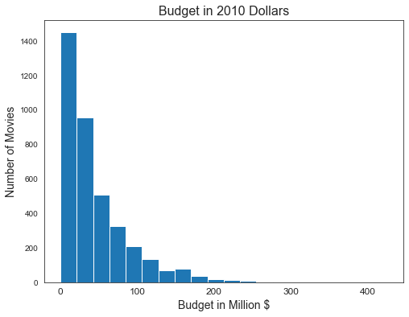

```python
# Plot the distribution of budget_adj
plot_hist(df_sub_100k['budget_adj']/1000000, 20, 'Budget in 2010 Dollars', 'Budget in Million $', 'Number of Movies')
```

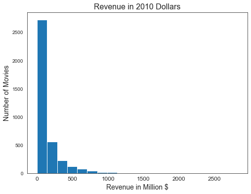

```python
# Plot the distribution of revenue_adj
plot_hist(df_sub_100k['revenue_adj']/1000000, 20, 'Revenue in 2010 Dollars', 'Revenue in Million $', 'Number of Movies')
```

Both budget_adj and revenue_adj are skewed to the right.

```
Correlation coefficient for linear regression: 0.57
```

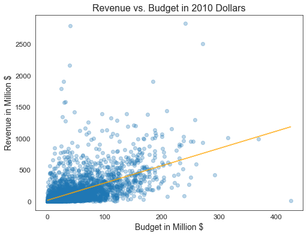

```python
# Create a scatter plot of budget vs. revenue
plot_scatter(df_sub_100k['budget_adj']/1000000, df_sub_100k['revenue_adj']/1000000, 'Revenue vs. Budget in 2010 Dollars', 'Budget in Million $', 'Revenue in Million $')
```

There is a positive correlation between budget and revenue - the higher the budget, the higher the revenue. However, there are some exceptions - movies with very high budget and extremely low revenue, and movies with rather low budget with high revenue. Out of curiosity, let's look at some of those movies:

```python
# View movies with budget_adj higher than or equal to 300 million dollars
df_sub_100k[['original_title', 'release_year', 'budget_adj', 'revenue_adj']].query('budget_adj >= 300000000').sort_values('budget_adj', ascending=False).head()
```

|  | original_title | release_year | budget_adj | revenue_adj |
| --- | --- | --- | --- | --- |
| 2244 | The Warrior's Way | 2010 | 4.250000e+08 | 1.108757e+07 |
| 3375 | Pirates of the Caribbean: On Stranger Tides | 2011 | 3.683713e+08 | 9.904175e+08 |
| 7387 | Pirates of the Caribbean: At World's End | 2007 | 3.155006e+08 | 1.010654e+09 |

The movie with title 'The Warrior's Way' has the highest budget, but revenue is quite low. The other two movies did much better.

```python
# View movies with revenue_adj higher than or equal to 2 milliard dollars
df_sub_100k[['original_title', 'release_year', 'budget_adj', 'revenue_adj']].query('revenue_adj >= 2000000000').sort_values('revenue_adj', ascending=False).head()
```

|  | original_title | release_year | budget_adj | revenue_adj |
| --- | --- | --- | --- | --- |
| 1386 | Avatar | 2009 | 2.408869e+08 | 2.827124e+09 |
| 1329 | Star Wars | 1977 | 3.957559e+07 | 2.789712e+09 |
| 5231 | Titanic | 1997 | 2.716921e+08 | 2.506406e+09 |
| 10594 | The Exorcist | 1973 | 3.928928e+07 | 2.167325e+09 |

There are only four movies with revenue_adj higher than 2 milliar dollars - and two of them were released in 1970s. Perhaps no surprise when looking at the first place.

Let's have a look on the revenue to budget ratio:

```python
# Create new dataframe to store the movie and its revenue_adj/budget_adj ratio
rvn_to_bdg = pd.DataFrame(columns = ['title', 'release_year', 'revenue_to_budget'])
rvn_to_bdg['title'] = df_sub_100k['original_title']
rvn_to_bdg['release_year'] = df_sub_100k['release_year']
rvn_to_bdg['genres'] = df_sub_100k['genres']
rvn_to_bdg['revenue_to_budget'] = df_sub_100k['revenue_adj']/df_sub_100k['budget_adj']

# Check the result
rvn_to_bdg.head()
```

|  | title | release_year | revenue_to_budget | genres |
| --- | --- | --- | --- | --- |
| 0 | Jurassic World | 2015 | 10.090192 | Action\|Adventure\|Science Fiction\|Thriller |
| 1 | Mad Max: Fury Road | 2015 | 2.522909 | Action\|Adventure\|Science Fiction\|Thriller |
| 2 | Insurgent | 2015 | 2.683984 | Adventure\|Science Fiction\|Thriller |
| 3 | Star Wars: The Force Awakens | 2015 | 10.340891 | Action\|Adventure\|Science Fiction\|Fantasy |
| 4 | Furious 7 | 2015 | 7.927628 | Action\|Crime\|Thriller |

Let's look at the top 10 movies:

```python
# Create top10 dataset
rvn_to_bdg_top10 = rvn_to_bdg.sort_values('revenue_to_budget', ascending=False).head(10)
rvn_to_bdg_top10
```

|  | title | release_year | revenue_to_budget | genres |
| --- | --- | --- | --- | --- |
| 7057 | Open Water | 2004 | 420.522723 | Drama\|Thriller |
| 9762 | The Texas Chain Saw Massacre | 1974 | 363.047059 | Horror\|Thriller |
| 7827 | Mad Max | 1979 | 250.000000 | Adventure\|Action\|Thriller\|Science Fiction |
| 10759 | Halloween | 1978 | 233.333333 | Horror\|Thriller |
| 10606 | American Graffiti | 1973 | 148.005148 | Comedy\|Drama |
| 7437 | Once | 2007 | 129.440706 | Drama\|Music\|Romance |
| 7087 | Napoleon Dynamite | 2004 | 115.295243 | Comedy |
| 6284 | Keeping Mum | 2005 | 109.850308 | Comedy |
| 1372 | The Hills Have Eyes | 1977 | 108.695652 | Horror |
| 7316 | Friday the 13th | 1980 | 108.644729 | Horror |

Visualize the result as a bar chart:

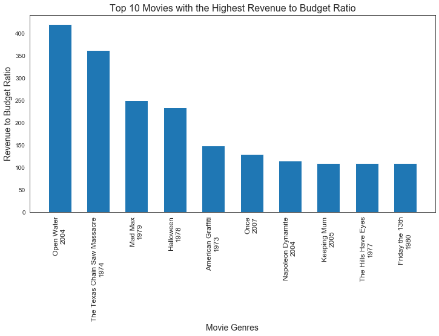

```python
# Create bar chart of the top 10 movies with respect to revenue_adj/budget_adj ratio
plot_bar_simple(data=rvn_to_bdg_top10, feature=rvn_to_bdg_top10['revenue_to_budget'], labels=rvn_to_bdg_top10['title']+'\n'+rvn_to_bdg_top10['release_year'].astype('str'),
                    bar_width=0.6, title='Top 10 Movies with the Highest Revenue to Budget Ratio',
                    x_label='Movie Genres', y_label='Revenue to Budget Ratio', x_label_rotation='vertical', dist=0)
```

The movie with the best revenue to budget ratio is a drama/thriller. The other movies are horrors/thrillers, horrors, comedies or comedy/drama, and two of them have features of adventure, action, science fiction, music and romance. Are the movies belonging to these genre categories the best ones when it comes to earnings or are they exceptions? What about other genres like crime, history, family, animation, war, or fantasy? Let's continue in our exploration.

### 2. Which genres are associated with high revenues?

Here we will try to find out which genres are the best ones when it comes to earnings. We will examine genres with the highest revenues, budgets and revenue-to-budget ratios.

#### Top 10 movie genres with respect to revenue

```python
# Calculate the average revenue and average budget by genres and select the top 10 genres with the highest average revenue
top10_rb = pd.DataFrame(df_sub_100k[['genres', 'budget_adj', 'revenue_adj']].groupby('genres').mean().sort_values(by='revenue_adj', ascending=False).head(10)).reset_index()
```

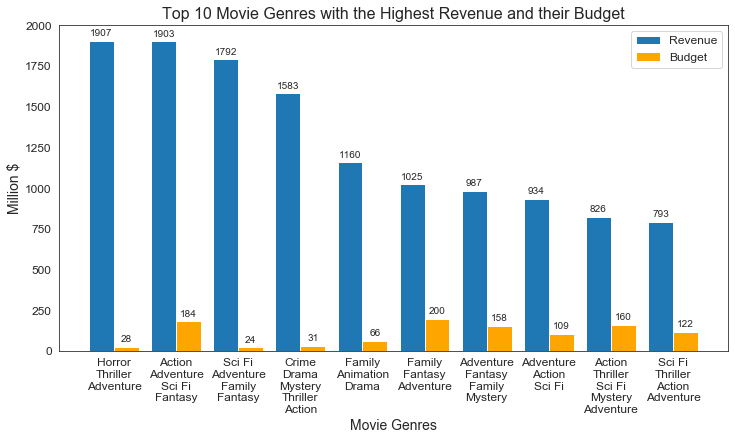

```python
# Plot the top 10 movie genres with the highest average revenue and respective average budget
plot_bar_combined(data=top10_rb, feature_1=top10_rb['revenue_adj'], feature_2=top10_rb['budget_adj'], scale=1000000,
                  labels=top10_rb['genres'].apply(lambda x: adjust_genres(x)),
                  title='Top 10 Movie Genres with the Highest Revenue and their Budget',
                  name_feature_1='Revenue', name_feature_2='Budget', x_label='Movie Genres', y_label='Million $', x_label_rotation='horizontal', dist=30)
```

The highest revenue movie genres are following:

- horror/thriller/adventure
- action/adventure/science fiction/fantasy
- science fiction/adventure/family/fantasy
- crime/drama/mystery/thriller/action

It looks like adventure and action in combination with genres like horror, thriller, fantasy, science fiction or even family are proper ingredients of a successful movie - they appear at almost all places in our top 10, except for the 5th place with family/animation/drama.

#### Top 10 movie genres with respect to budget

Budget doesn't say anything about revenue. However, the lower the budget and the higher the revenue, the better.

```python
# Calculate the average revenue and average budget by genres and select the top 10 genres with the highest average budget
top10_br = pd.DataFrame(df_sub_100k[['genres', 'budget_adj', 'revenue_adj']].groupby('genres').mean().sort_values(by='budget_adj', ascending=False).head(10)).reset_index()
```

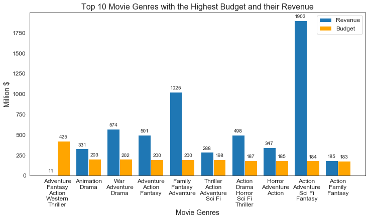

```python
# Plot the top 10 movie genres with the highest average budget and respective average revenue
plot_bar_combined(data=top10_br, feature_1=top10_br['revenue_adj'], feature_2=top10_br['budget_adj'], scale=1000000,
                  labels=top10_br['genres'].apply(lambda x: adjust_genres(x)),
                  title='Top 10 Movie Genres with the Highest Budget and their Revenue',
                  name_feature_1='Revenue', name_feature_2='Budget', x_label='Movie Genres', y_label='Million $', x_label_rotation='horizontal', dist=30)
```

It is easily observable that high budget does not necessarily mean high revenue - and there are only two genres that occurred also in the above top 10 of the highest revenue movie genres. However, all but one genre category had higher revenues than budget. Well, one probably would not like to make a movie with elements of action, adventure, fantasy, thriller, and western.

#### Top 10 movie genres with respect to revenue-to-budget ratio

Let's look at the ratios between the movie revenue and budget, and pick the best 10 movie genres.

```python
# Calculate the average revenue to average budget ratio by genres and select the top 10 genres
rb_ratio = pd.DataFrame(df_sub_100k[['genres', 'budget_adj', 'revenue_adj']].groupby('genres').mean()).reset_index()
rb_ratio['ratio'] = rb_ratio['revenue_adj']/rb_ratio['budget_adj']
top10_rb_ratio = rb_ratio.sort_values(by='ratio', ascending=False).head(10)
```

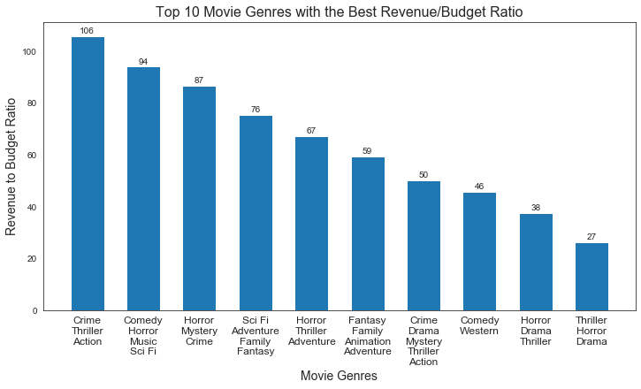

```python
# Visualize the result
plot_bar_simple(data=top10_rb_ratio, feature=top10_rb_ratio['ratio'], labels=top10_rb_ratio['genres'].apply(lambda x: adjust_genres(x)),
                bar_width=0.6, title='Top 10 Movie Genres with the Best Revenue/Budget Ratio', x_label='Movie Genres', y_label='Revenue to Budget Ratio',
                x_label_rotation='horizontal', dist=1)
```

Direct comparison of revenue and budget gives an additional insight - the best genre from this point of view is crime/thriller/action, followed by comedy/horror/music/science fiction (hm, this is a strange combination) and horror/mystery/crime. However, now we do not have information about actual revenues and budgets. Let's repeat this with the two separate datasets for high- and low-budget movies.

##### High- and low-budget movies

First, calculate the ratios for both datasets:

```python
# Calculate the average revenue to average budget ratio by genres and select the top 10 genres for high budget movies
rb_ratio_high = pd.DataFrame(df_sub_high_bdg[['genres', 'budget_adj', 'revenue_adj']].groupby('genres').mean()).reset_index()
rb_ratio_high['ratio'] = rb_ratio_high['revenue_adj']/rb_ratio_high['budget_adj']
top10_rb_ratio_high = rb_ratio_high.sort_values(by='ratio', ascending=False).head(10)
top10_rb_ratio_high
```

|  | genres | budget_adj | revenue_adj | ratio |
| --- | --- | --- | --- | --- |
| 404 | Crime\|Drama\|Mystery\|Thriller\|Action | 3.148127e+07 | 1.583050e+09 | 50.285439 |
| 472 | Drama\|Horror\|Thriller | 3.639309e+07 | 1.097884e+09 | 30.167366 |
| 220 | Adventure\|Comedy\|Science Fiction\|Family | 3.851615e+07 | 7.725728e+08 | 20.058409 |
| 237 | Adventure\|Drama\|Western | 3.671577e+07 | 7.079615e+08 | 19.282220 |
| 316 | Animation\|Family\|Comedy\|Adventure\|Fantasy | 4.351268e+07 | 7.833063e+08 | 18.001794 |
| 521 | Family\|Animation\|Drama | 6.620002e+07 | 1.159592e+09 | 17.516484 |
| 589 | History\|Drama\|Western\|Crime | 3.566559e+07 | 6.081511e+08 | 17.051482 |
| 374 | Comedy\|Music\|Family\|Fantasy | 4.218160e+07 | 7.190046e+08 | 17.045454 |
| 703 | Thriller\|Action\|Drama\|Music\|Romance | 3.885061e+07 | 6.387144e+08 | 16.440270 |
| 646 | Romance\|Comedy\|Crime\|Fantasy | 3.383557e+07 | 5.172184e+08 | 15.286235 |

```python
# Calculate the average revenue to average budget ratio by genres and select the top 10 genres for high budget movies
rb_ratio_low = pd.DataFrame(df_sub_low_bdg[['genres', 'budget_adj', 'revenue_adj']].groupby('genres').mean()).reset_index()
rb_ratio_low['ratio'] = rb_ratio_low['revenue_adj']/rb_ratio_low['budget_adj']
top10_rb_ratio_low = rb_ratio_low.sort_values(by='ratio', ascending=False).head(10)
top10_rb_ratio_low
```

|  | genres | budget_adj | revenue_adj | ratio |
| --- | --- | --- | --- | --- |
| 246 | Crime\|Thriller\|Action | 4.174486e+06 | 4.420044e+08 | 105.882353 |
| 199 | Comedy\|Horror\|Music\|Science Fiction | 4.862185e+06 | 4.574195e+08 | 94.076933 |
| 410 | Horror\|Mystery\|Crime | 1.385334e+06 | 1.199603e+08 | 86.593058 |
| 487 | Thriller\|Action\|Comedy\|Crime\|Drama | 2.259642e+06 | 1.782146e+08 | 78.868508 |
| 470 | Science Fiction\|Adventure\|Family\|Fantasy | 2.372625e+07 | 1.791694e+09 | 75.515291 |
| 421 | Horror\|Thriller\|Adventure | 2.836275e+07 | 1.907006e+09 | 67.236286 |
| 110 | Adventure\|Action\|Thriller\|Science Fiction | 2.999102e+06 | 1.797264e+08 | 59.926761 |
| 380 | Fantasy\|Family\|Animation\|Adventure | 4.317337e+06 | 2.562191e+08 | 59.346557 |
| 97 | Action\|Thriller\|Drama | 7.000753e+06 | 3.891681e+08 | 55.589466 |
| 111 | Adventure\|Animation\|Comedy\|Family | 2.917944e+07 | 1.574815e+09 | 53.970003 |

There are different genres in the top 10 lists for high- and low-budget movies. Next, we will merge the two datasets back into one dataset, and we will plot the top 10 movie genres for high-budget movies along with their low-budget counterparts, and the top 10 movie genres for low-budget movies along with their high-budget counterparts.

```python
# Prepare dataframes for merging - rename ratio columns
rb_ratio_high.rename(columns={'ratio':'ratio_high'},inplace=True)
rb_ratio_low.rename(columns={'ratio':'ratio_low'},inplace=True)
```

We use outer join to keep all the genres:

```python
# Merge the dataframes
merged = rb_ratio_high.merge(rb_ratio_low, on='genres', how='outer')

# Check the result
merged.head()
```

|  | genres | budget_adj_x | revenue_adj_x | ratio_high | budget_adj_y | revenue_adj_y | ratio_low |
| --- | --- | --- | --- | --- | --- | --- | --- |
| 0 | Action | 7.740819e+07 | 1.476859e+08 | 1.907885 | 1.236309e+07 | 1.346451e+07 | 1.089089 |
| 1 | Action\|Adventure | 8.463168e+07 | 9.673360e+07 | 1.142995 | 1.695104e+07 | 2.239339e+08 | 13.210627 |
| 2 | Action\|Adventure\|Animation\|Family\|Fantasy | 1.260217e+08 | 5.380038e+08 | 4.269134 | NaN | NaN | NaN |
| 3 | Action\|Adventure\|Animation\|Family\|Science Fiction | 1.062090e+08 | 7.289654e+08 | 6.863501 | NaN | NaN | NaN |
| 4 | Action\|Adventure\|Animation\|Science Fiction\|Thr... | 3.049201e+07 | 4.922230e+07 | 1.614269 | NaN | NaN | NaN |

```python
# Replace nan with zero
merged.replace(np.nan,0, inplace=True)

# Check the resuls
merged.head()
```

|  | genres | budget_adj_x | revenue_adj_x | ratio_high | budget_adj_y | revenue_adj_y | ratio_low |
| --- | --- | --- | --- | --- | --- | --- | --- |
| 0 | Action | 7.740819e+07 | 1.476859e+08 | 1.907885 | 1.236309e+07 | 1.346451e+07 | 1.089089 |
| 1 | Action\|Adventure | 8.463168e+07 | 9.673360e+07 | 1.142995 | 1.695104e+07 | 2.239339e+08 | 13.210627 |
| 2 | Action\|Adventure\|Animation\|Family\|Fantasy | 1.260217e+08 | 5.380038e+08 | 4.269134 | 0.000000e+00 | 0.000000e+00 | 0.000000 |
| 3 | Action\|Adventure\|Animation\|Family\|Science Fiction | 1.062090e+08 | 7.289654e+08 | 6.863501 | 0.000000e+00 | 0.000000e+00 | 0.000000 |
| 4 | Action\|Adventure\|Animation\|Science Fiction\|Thr... | 3.049201e+07 | 4.922230e+07 | 1.614269 | 0.000000e+00 | 0.000000e+00 | 0.000000 |

**High-budget movies with the best revenue-to-budget ratio**

```python
# Prepare top 10 movie genre dataframe - high-budget movies
merged_sort_high_top10 = merged.sort_values('ratio_high', ascending=False).head(10)
```

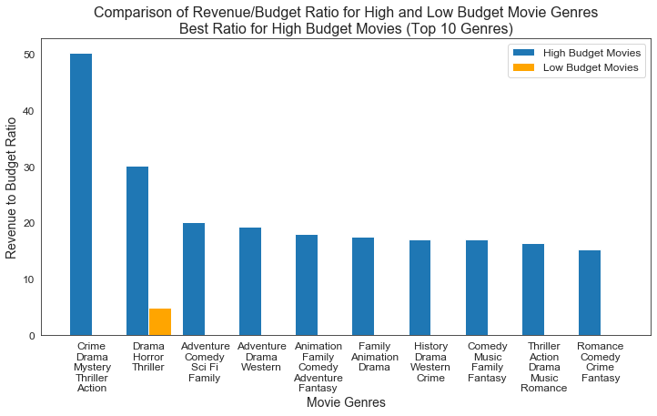

```python
# Create bar chart to visualize the best movies in the low-budget category
plot_bar_combined(data=merged_sort_high_top10, feature_1=merged_sort_high_top10['ratio_high'], feature_2=merged_sort_high_top10['ratio_low'], scale=1,
                  labels=merged_sort_high_top10['genres'].apply(lambda x: adjust_genres(x)),
                  title='Comparison of Revenue/Budget Ratio for High and Low Budget Movie Genres\nBest Ratio for High Budget Movies (Top 10 Genres)',
                  name_feature_1='High Budget Movies', name_feature_2='Low Budget Movies', x_label='Movie Genres', y_label='Revenue to Budget Ratio',
                  x_label_rotation='horizontal', dist=0)
```

**Low-budget movies with the best revenue-to-budget ratio**

```python
# Prepare top 10 movie genre dataframe - low-budget movies
merged_sort_low_top10 = merged.sort_values('ratio_low', ascending=False).head(10)
```

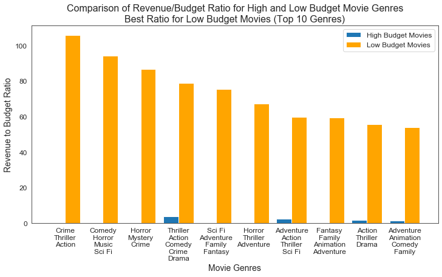

```python
# Create bar chart to visualize the best movies in the low-budget category
plot_bar_combined(data=merged_sort_low_top10, feature_1=merged_sort_low_top10['ratio_high'], feature_2=merged_sort_low_top10['ratio_low'], scale=1,
                  labels=merged_sort_low_top10['genres'].apply(lambda x: adjust_genres(x)),
                  title='Comparison of Revenue/Budget Ratio for High and Low Budget Movie Genres\nBest Ratio for Low Budget Movies (Top 10 Genres)',
                  name_feature_1='High Budget Movies', name_feature_2='Low Budget Movies', x_label='Movie Genres', y_label='Revenue to Budget Ratio',
                  x_label_rotation='horizontal', dist=0)
```

### 3. What is the optimal movie runtime with respect to revenue?

Let's look at a different movie feature - runtime.

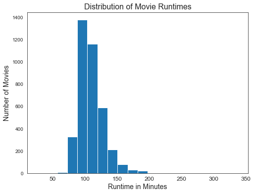

```python
# Plot distribution of movie runtime
plot_hist(x=df_sub_100k['runtime'], number_of_bins=20, title='Distribution of Movie Runtimes', x_label='Runtime in Minutes', y_label='Number of Movies')
```

The distribution of movie runtime is slightly skewed to the right; most of the movies have something about 90-150 minutes.

```
Correlation coefficient for linear regression: 0.28
```

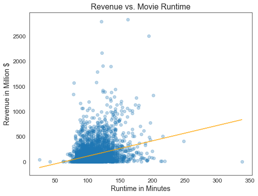

```python
# Create scatter plot to show relation between revenue and runtime
plot_scatter(df_sub_100k['runtime'], df_sub_100k['revenue_adj']/1000000, 'Revenue vs. Movie Runtime', 'Runtime in Minutes', 'Revenue in Million $')
```

It looks like the movie revenue is not dependent on its runtime - the correlation coefficient is rather small. Let's look at this from another angle - create a plot showing the average revenue for runtimes categorized into several intervals:

```python
# Calculate min and max runtime
min_runtime = df_sub_100k['runtime'].min()
max_runtime = df_sub_100k['runtime'].max()
print('Min runtime: {}'.format(min_runtime))
print('Max runtime: {}'.format(max_runtime))
```

```
Min runtime: 26.0
Max runtime: 338.0
```

```python
# Look at the unique runtime values
df_sub_100k['runtime'].unique()
```

```
array([124., 120., 119., 136., 137., 156., 125., 141.,  91.,  94., 148.,
       108., 105., 167., 109., 115., 112., 130., 123., 114., 131., 128.,
       132., 103., 117.,  93., 111., 147., 106., 122., 116.,  97., 118.,
       121., 100., 133.,  92.,  96., 102.,  88.,  99.,  89., 107.,  95.,
       104., 101.,  98., 113.,  82.,  87.,  90., 134.,  83.,  78., 129.,
       169., 144., 145., 135., 139., 165., 142., 153., 127., 110., 164.,
       138.,  84.,  81.,  79.,  85.,  86., 175.,  80., 162., 158., 140.,
       161., 170., 150., 146.,  77., 338., 189., 157., 159., 126., 188.,
        74., 178., 152., 183., 166.,  75., 213., 160.,  42., 155.,  63.,
       154., 149.,  62., 179.,  72.,  73., 191.,  76., 171., 143., 172.,
       201., 214., 194., 177., 180., 187., 151., 163.,  66., 219., 193.,
        26., 192., 202., 195.,  69., 200., 184., 216., 181.,  71., 186.,
       168., 197., 248., 174., 199., 182.])
```

```python
# Create a list of bins that will be used to create categories from runtime
list_of_bins = []

start=25
step=25

for i in np.arange(start, max_runtime.astype('int'), step):
    list_of_bins.append((i, i+step))

bins = pd.IntervalIndex.from_tuples(list_of_bins)
bins
```

```
IntervalIndex([(25, 50], (50, 75], (75, 100], (100, 125], (125, 150] ... (225, 250], (250, 275], (275, 300], (300, 325], (325, 350]],
              closed='right',
              dtype='interval[int64]')
```

```python
# Create an additional column to represent movie runtime in terms of intervals/categories
df_sub_100k['runtime_cat'] = pd.cut(df_sub_100k['runtime'], bins)
df_sub_100k.head()
```

|  | id | original_title | runtime | genres | vote_average | release_year | budget_adj | revenue_adj | runtime_cat |
| --- | --- | --- | --- | --- | --- | --- | --- | --- | --- |
| 0 | 135397 | Jurassic World | 124.0 | Action\|Adventure\|Science Fiction\|Thriller | 6.5 | 2015 | 1.379999e+08 | 1.392446e+09 | (100, 125] |
| 1 | 76341 | Mad Max: Fury Road | 120.0 | Action\|Adventure\|Science Fiction\|Thriller | 7.1 | 2015 | 1.379999e+08 | 3.481613e+08 | (100, 125] |
| 2 | 262500 | Insurgent | 119.0 | Adventure\|Science Fiction\|Thriller | 6.3 | 2015 | 1.012000e+08 | 2.716190e+08 | (100, 125] |
| 3 | 140607 | Star Wars: The Force Awakens | 136.0 | Action\|Adventure\|Science Fiction\|Fantasy | 7.5 | 2015 | 1.839999e+08 | 1.902723e+09 | (125, 150] |
| 4 | 168259 | Furious 7 | 137.0 | Action\|Crime\|Thriller | 7.3 | 2015 | 1.747999e+08 | 1.385749e+09 | (125, 150] |

```python
# Group movies by runtime interval categories, calculate average revenue_adj and store the results
run_cat = df_sub_100k[['runtime_cat', 'revenue_adj']].groupby('runtime_cat').mean().reset_index()

# Replace nan with zero value
run_cat.replace(np.nan, 0, inplace=True)

# View the result
run_cat
```

|  | runtime_cat | revenue_adj |
| --- | --- | --- |
| 0 | (25, 50] | 2.298778e+07 |
| 1 | (50, 75] | 6.031075e+07 |
| 2 | (75, 100] | 9.444034e+07 |
| 3 | (100, 125] | 1.278516e+08 |
| 4 | (125, 150] | 2.449571e+08 |
| 5 | (150, 175] | 3.481554e+08 |
| 6 | (175, 200] | 3.556538e+08 |
| 7 | (200, 225] | 3.239053e+08 |
| 8 | (225, 250] | 4.111904e+08 |
| 9 | (250, 275] | 0.000000e+00 |
| 10 | (275, 300] | 0.000000e+00 |
| 11 | (300, 325] | 0.000000e+00 |
| 12 | (325, 350] | 8.712790e+05 |

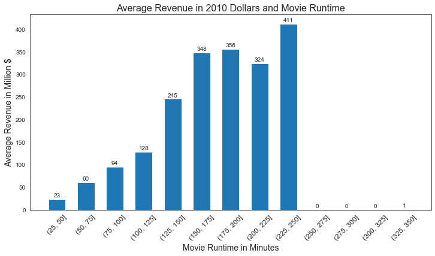

```python
# Visualize the average revenue_adj with respect to movie runtime
plot_bar_simple(data=run_cat, feature=run_cat['revenue_adj']/1000000, labels=run_cat['runtime_cat'],
                bar_width=0.6, title='Average Revenue in 2010 Dollars and Movie Runtime',
                x_label='Movie Runtime in Minutes', y_label='Average Revenue in Million $',
                x_label_rotation='45', dist=5)
```

Movies with runtimes between 125-250 minutes have the highest revenues. It's quite a broad interval. Based on these observations, it looks like the runtime is not so important when it comes to assessing movie revenues. However, more sophisticated methods might be required to deliver deeper insights.

### 4. Are movies with high revenues rated highly by users?

Finally, what is the opinion of people (or, better to say, users of the movie database webpage)?

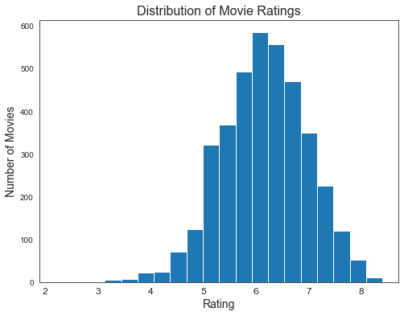

```python
# Plot distribution of movie ratings
plot_hist(x=df_sub_100k['vote_average'], number_of_bins=20, title='Distribution of Movie Ratings', x_label='Rating', y_label='Number of Movies')
```

Movie ratings follow normal distribution with center about 6.

```
Correlation coefficient for linear regression: 0.27
```

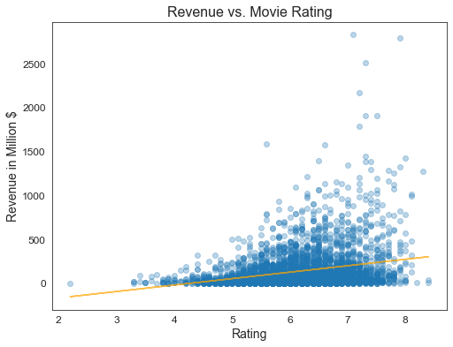

```python
# Create scatter plot to show relation between revenue and rating
plot_scatter(df_sub_100k['vote_average'], df_sub_100k['revenue_adj']/1000000, 'Revenue vs. Movie Rating', 'Rating', 'Revenue in Million $')
```

It seems that higher revenue might be connected with better rating. However, the correlation coefficient for linear regression is rather small. Let's create categories out of ratings, similar to runtime above, and compare the average revenues among these categories:

```python
# Calculate min and max rating
min_rate = df_sub_100k['vote_average'].min()
max_rate = df_sub_100k['vote_average'].max()
print('Min min_rate: {}'.format(min_rate))
print('Max max_rate: {}'.format(max_rate))
```

```
Min min_rate: 2.2
Max max_rate: 8.4
```

```python
# Create a list of bins that will be used to create rating categories
list_of_bins = []

start=2
step=1

for i in np.arange(start, max_rate.astype('int')+1, step):
    list_of_bins.append((i, i+step))

bins = pd.IntervalIndex.from_tuples(list_of_bins)
bins
```

```
IntervalIndex([(2, 3], (3, 4], (4, 5], (5, 6], (6, 7], (7, 8], (8, 9]],
              closed='right',
              dtype='interval[int64]')
```

```python
# Create an additional column to represent movie runtime in terms of intervals/categories
df_sub_100k['rate_cat'] = pd.cut(df_sub_100k['vote_average'], bins)
df_sub_100k.head()
```

|  | id | original_title | runtime | genres | vote_average | release_year | budget_adj | revenue_adj | runtime_cat | rate_cat |
| --- | --- | --- | --- | --- | --- | --- | --- | --- | --- | --- |
| 0 | 135397 | Jurassic World | 124.0 | Action\|Adventure\|Science Fiction\|Thriller | 6.5 | 2015 | 1.379999e+08 | 1.392446e+09 | (100, 125] | (6, 7] |
| 1 | 76341 | Mad Max: Fury Road | 120.0 | Action\|Adventure\|Science Fiction\|Thriller | 7.1 | 2015 | 1.379999e+08 | 3.481613e+08 | (100, 125] | (7, 8] |
| 2 | 262500 | Insurgent | 119.0 | Adventure\|Science Fiction\|Thriller | 6.3 | 2015 | 1.012000e+08 | 2.716190e+08 | (100, 125] | (6, 7] |
| 3 | 140607 | Star Wars: The Force Awakens | 136.0 | Action\|Adventure\|Science Fiction\|Fantasy | 7.5 | 2015 | 1.839999e+08 | 1.902723e+09 | (125, 150] | (7, 8] |
| 4 | 168259 | Furious 7 | 137.0 | Action\|Crime\|Thriller | 7.3 | 2015 | 1.747999e+08 | 1.385749e+09 | (125, 150] | (7, 8] |

```python
# Group movies by rating categories, calculate average revenue_adj and store the results
rat_cat = df_sub_100k[['rate_cat', 'revenue_adj']].groupby('rate_cat').mean().reset_index()

# Replace nan with zero value
rat_cat.replace(np.nan, 0, inplace=True)

# View the result
rat_cat
```

|  | rate_cat | revenue_adj |
| --- | --- | --- |
| 0 | (2, 3] | 7.000185e+04 |
| 1 | (3, 4] | 2.708082e+07 |
| 2 | (4, 5] | 4.772866e+07 |
| 3 | (5, 6] | 9.860983e+07 |
| 4 | (6, 7] | 1.487504e+08 |
| 5 | (7, 8] | 2.581792e+08 |
| 6 | (8, 9] | 4.496938e+08 |

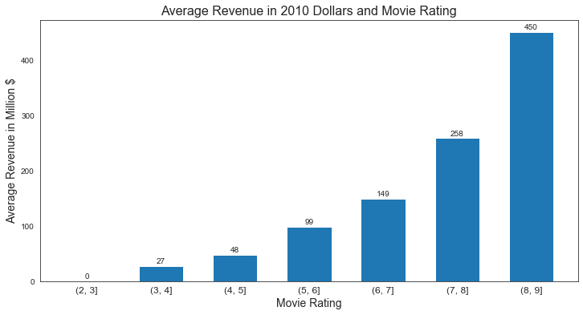

```python
# Visualize the average revenue_adj with respect to movie rating
plot_bar_simple(data=rat_cat, feature=rat_cat['revenue_adj']/1000000, labels=rat_cat['rate_cat'],
                bar_width=0.6, title='Average Revenue in 2010 Dollars and Movie Rating',
                x_label='Movie Rating', y_label='Average Revenue in Million $',
                x_label_rotation='horizontal', dist=5)
```

The bar chart shows that the better the rating, the higher the average revenue - movies with the highest ratings have also highest revenues on average. On the other hand, poorly rated movies have also low average revenue. However, these are just the basic visualizations and more sophisticated approach would provide better insights.

## Conclusions

In this project, we have explored and analyzed the movie dataset. The analysis was built around four questions related to movie revenues, budgets, genres, ratings and runtimes, and these questions were approached by descriptive statistics.

**Revenue vs. budget.** Correlation between the revenue and budget is positive. That is, the higher the budget, the higher the revenue. However, the relationship is not uniform, and there are exceptions - movies with extremely high budgets and low revenues, or movies with extremely high revenues, but low budgets.

**Revenue vs. runtime.** Next, we looked on the correlation between revenue and runtime. There is quite a broad interval of runtimes, 125-250 minutes, that is characteristic for movies with the highest revenues. Because of this, runtime is probably not a very specific measure for the movie success.

**Revenue vs. user rating.** In the last part, the relation between the movie revenue and user ratings was explored. Generally, the better the rating, the higher the revenue. On the other side, poorly rated movies had also lower revenues.

Exploratory analysis revealed some interesting insights into the studied dataset. However, more sophisticated approach including inferential statistics and/or machine learning techniques would be necessary to gain better understanding of the data and draw final conclusions.